# Predicting Mortality in Heart Failure Patients

Michael Matyevich

2026-04-06

## Background

Heart failure is a condition where the heart cannot pump enough blood to meet the body’s needs. It is a leading cause of hospitalisation and death worldwide, and identifying which patients are at highest risk of dying allows clinicians to prioritise monitoring and intervention resources more effectively.

## Research Questions

**RQ1 — Which clinical measurements are most strongly associated with mortality in heart failure patients?**

Understanding which variables matter most guides both clinical triage and future data collection priorities. If a small number of cheap, routine measurements can predict mortality accurately, that has immediate practical value.

**RQ2 — Does LASSO variable selection produce a more parsimonious model without meaningfully sacrificing predictive performance compared to a full model?**

Simpler models are easier to explain to clinicians, less likely to overfit on small datasets, and cheaper to implement in practice. LASSO is a principled way to find a minimal sufficient predictor set — we compare it directly to the full model.

**RQ3 — Do linear discriminant methods (LDA, QDA) perform competitively with logistic regression for this classification task?**

LDA and QDA make different assumptions about the data compared to logistic regression. Testing all three helps us understand whether the distributional assumptions underlying each method are supported by this dataset.

## Dataset Description

The dataset contains **299 hospitalised heart failure patients** with 13 variables recorded during follow-up. The outcome is `DEATH_EVENT` — whether the patient died during the follow-up period (1 = died, 0 = survived).

| Variable | Type | Description |
| --- | --- | --- |
| age | Numeric | Age at time of hospitalisation (years) |
| anaemia | Binary | Whether the patient has anaemia (0/1) |
| creatinine_phosphokinase | Numeric | Level of CPK enzyme in blood (mcg/L) |
| diabetes | Binary | Whether the patient has diabetes (0/1) |
| ejection_fraction | Numeric | % of blood leaving heart per contraction |
| high_blood_pressure | Binary | Whether the patient has hypertension (0/1) |
| platelets | Numeric | Platelet count (kiloplatelets/mL) |
| serum_creatinine | Numeric | Level of creatinine in blood (mg/dL) |
| serum_sodium | Numeric | Level of sodium in blood (mEq/L) |
| sex | Binary | Biological sex (0 = female, 1 = male) |
| smoking | Binary | Whether the patient smokes (0/1) |
| time | Numeric | Follow-up period in days |
| DEATH_EVENT | Binary | **Outcome** — died during follow-up (1 = yes) |

The class split is approximately **67% survived and 33% died** — a moderate imbalance that means a naive model predicting “survived” for everyone would achieve 67% accuracy without learning anything. This is why we use metrics beyond simple accuracy (sensitivity, specificity, AUC-ROC) to evaluate performance.

## Exploratory Analysis

```r
str(hfc_records)
```

```
## 'data.frame':    299 obs. of  13 variables:
##  $ age                     : num  75 55 65 50 65 90 75 60 65 80 ...
##  $ anaemia                 : int  0 0 0 1 1 1 1 1 0 1 ...
##  $ creatinine_phosphokinase: int  582 7861 146 111 160 47 246 315 157 123 ...
##  $ diabetes                : int  0 0 0 0 1 0 0 1 0 0 ...
##  $ ejection_fraction       : int  20 38 20 20 20 40 15 60 65 35 ...
##  $ high_blood_pressure     : int  1 0 0 0 0 1 0 0 0 1 ...
##  $ platelets               : num  265000 263358 162000 210000 327000 ...
##  $ serum_creatinine        : num  1.9 1.1 1.3 1.9 2.7 2.1 1.2 1.1 1.5 9.4 ...
##  $ serum_sodium            : int  130 136 129 137 116 132 137 131 138 133 ...
##  $ sex                     : int  1 1 1 1 0 1 1 1 0 1 ...
##  $ smoking                 : int  0 0 1 0 0 1 0 1 0 1 ...
##  $ time                    : int  4 6 7 7 8 8 10 10 10 10 ...
##  $ DEATH_EVENT             : int  1 1 1 1 1 1 1 1 1 1 ...
```

```r
summary(hfc_records)
```

```
##       age           anaemia       creatinine_phosphokinase    diabetes
##  Min.   :40.00   Min.   :0.0000   Min.   :  23.0           Min.   :0.0000
##  1st Qu.:51.00   1st Qu.:0.0000   1st Qu.: 116.5           1st Qu.:0.0000
##  Median :60.00   Median :0.0000   Median : 250.0           Median :0.0000
##  Mean   :60.83   Mean   :0.4314   Mean   : 581.8           Mean   :0.4181
##  3rd Qu.:70.00   3rd Qu.:1.0000   3rd Qu.: 582.0           3rd Qu.:1.0000
##  Max.   :95.00   Max.   :1.0000   Max.   :7861.0           Max.   :1.0000
##  ejection_fraction high_blood_pressure   platelets      serum_creatinine
##  Min.   :14.00     Min.   :0.0000      Min.   : 25100   Min.   :0.500
##  1st Qu.:30.00     1st Qu.:0.0000      1st Qu.:212500   1st Qu.:0.900
##  Median :38.00     Median :0.0000      Median :262000   Median :1.100
##  Mean   :38.08     Mean   :0.3512      Mean   :263358   Mean   :1.394
##  3rd Qu.:45.00     3rd Qu.:1.0000      3rd Qu.:303500   3rd Qu.:1.400
##  Max.   :80.00     Max.   :1.0000      Max.   :850000   Max.   :9.400
##   serum_sodium        sex            smoking            time
##  Min.   :113.0   Min.   :0.0000   Min.   :0.0000   Min.   :  4.0
##  1st Qu.:134.0   1st Qu.:0.0000   1st Qu.:0.0000   1st Qu.: 73.0
##  Median :137.0   Median :1.0000   Median :0.0000   Median :115.0
##  Mean   :136.6   Mean   :0.6488   Mean   :0.3211   Mean   :130.3
##  3rd Qu.:140.0   3rd Qu.:1.0000   3rd Qu.:1.0000   3rd Qu.:203.0
##  Max.   :148.0   Max.   :1.0000   Max.   :1.0000   Max.   :285.0
##   DEATH_EVENT
##  Min.   :0.0000
##  1st Qu.:0.0000
##  Median :0.0000
##  Mean   :0.3211
##  3rd Qu.:1.0000
##  Max.   :1.0000
```

```r
hfc_records$DEATH_EVENT <- as.factor(hfc_records$DEATH_EVENT)
colSums(is.na(hfc_records))
```

```
##                      age                  anaemia creatinine_phosphokinase
##                        0                        0                        0
##                 diabetes        ejection_fraction      high_blood_pressure
##                        0                        0                        0
##                platelets         serum_creatinine             serum_sodium
##                        0                        0                        0
##                      sex                  smoking                     time
##                        0                        0                        0
##              DEATH_EVENT
##                        0
```

There are **no missing values** in this dataset, so no imputation is required.

```r
# Scale numeric variables so LDA / QDA will have equal weighting.
# Without scaling, variables measured on larger scales (e.g. creatinine_phosphokinase
# which can reach tens of thousands) would dominate the distance calculations
# that LDA and QDA rely on, simply because of their units rather than their
# actual predictive value.
numeric_vars <- c("age", "creatinine_phosphokinase", "ejection_fraction",
                  "platelets", "serum_creatinine", "serum_sodium", "time")
hfc_records[numeric_vars] <- scale(hfc_records[numeric_vars])

table(hfc_records$DEATH_EVENT)
```

```
##
##   0   1
## 203  96
```

The class distribution confirms the 67/33 split noted above. This is worth keeping in mind throughout — in a clinical context, the *cost of a false negative* (predicting “survived” when the patient actually dies) is much higher than the cost of a false positive. We will pay particular attention to **sensitivity** (the model’s ability to correctly identify deaths) when comparing models.

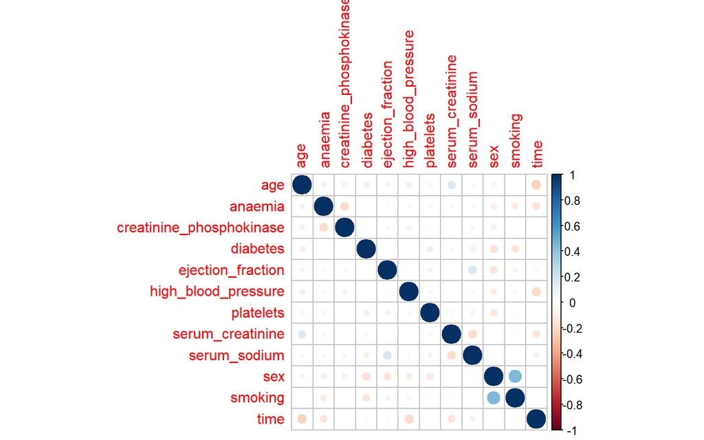

```r
cor_matrix <- cor(hfc_records |> dplyr::select(-DEATH_EVENT))
corrplot(cor_matrix)
```

The correlation matrix shows mostly weak relationships between predictors, which is good — it means we are unlikely to have severe multicollinearity issues where two variables are measuring nearly the same thing and destabilising coefficient estimates.

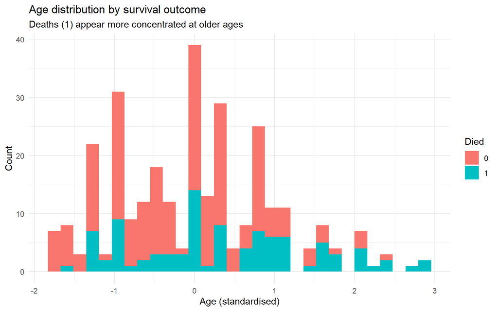

```r
ggplot(hfc_records, aes(age, fill = DEATH_EVENT)) +
  geom_histogram(bins = 30) +
  labs(title = "Age distribution by survival outcome",
       subtitle = "Deaths (1) appear more concentrated at older ages",
       x = "Age (standardised)", y = "Count", fill = "Died") +
  theme_minimal()
```

The age histogram gives an early indication that older patients are over-represented in the death group, consistent with age being a known risk factor in heart failure prognosis. However, the overlap between groups is substantial — age alone will not be sufficient to classify patients accurately.

## Train / Test Split

```r
train_set <- createDataPartition(hfc_records$DEATH_EVENT, p = 0.8, list = FALSE)
train <- hfc_records[train_set, ]
test  <- hfc_records[-train_set, ]
```

We partition the data into **80% training (~239 patients)** and **20% test (~60 patients)**. `createDataPartition` stratifies by the outcome variable, which preserves the 67/33 class ratio in both partitions. The test set is sealed from all modelling decisions — it is only used once at the end to report final performance.

With only 299 patients total, this is a small dataset. Small samples mean performance estimates from a single split can be noisy — a handful of patients in the test set landing on one side or the other of the boundary can swing accuracy by several percentage points. This is precisely why we use **10-fold cross-validation** rather than relying on the split alone.

## Logistic Regression

Logistic regression models the *probability* that a patient dies, as a function of their clinical measurements. It is the standard first-line tool for binary clinical outcomes because its coefficients have a direct interpretation: each coefficient represents the change in the log-odds of death for a one-unit increase in that predictor, holding all others constant.

```r
log_model <- glm(DEATH_EVENT ~ ., data = train, family = binomial)
summary(log_model)
```

```
##
## Call:
## glm(formula = DEATH_EVENT ~ ., family = binomial, data = train)
##
## Coefficients:
##                          Estimate Std. Error z value Pr(>|z|)
## (Intercept)              -1.22192    0.50066  -2.441   0.0147 *
## age                       0.54717    0.22253   2.459   0.0139 *
## anaemia                  -0.05804    0.42351  -0.137   0.8910
## creatinine_phosphokinase  0.21174    0.18832   1.124   0.2608
## diabetes                  0.48053    0.40521   1.186   0.2357
## ejection_fraction        -0.96279    0.22823  -4.219 2.46e-05 ***
## high_blood_pressure      -0.63545    0.44716  -1.421   0.1553
## platelets                -0.07964    0.21447  -0.371   0.7104
## serum_creatinine          0.41814    0.26110   1.601   0.1093
## serum_sodium             -0.37258    0.19716  -1.890   0.0588 .
## sex                      -0.21123    0.48253  -0.438   0.6616
## smoking                  -0.30466    0.48756  -0.625   0.5321
## time                     -1.91791    0.29437  -6.515 7.26e-11 ***
## ---
## Signif. codes:  0 '***' 0.001 '**' 0.01 '*' 0.05 '.' 0.1 ' ' 1
##
## (Dispersion parameter for binomial family taken to be 1)
##
##     Null deviance: 301.20  on 239  degrees of freedom
## Residual deviance: 167.82  on 227  degrees of freedom
## AIC: 193.82
##
## Number of Fisher Scoring iterations: 6
```

The `time` variable deserves a note: it represents how long the patient was followed up, which partly reflects survival itself. In a prospective clinical model this would require careful handling, but for this predictive exercise we retain it.

```r
# Stepwise AIC reduces the model to a smaller set of predictors.
# AIC (Akaike Information Criterion) penalises model complexity — adding a predictor
# only "pays off" if it improves fit enough to justify the added parameter.
# The "both" direction means variables can be added or removed at each step.
step_model <- step(log_model, direction = "both")
```

```
## Start:  AIC=193.82
## DEATH_EVENT ~ age + anaemia + creatinine_phosphokinase + diabetes +
##     ejection_fraction + high_blood_pressure + platelets + serum_creatinine +
##     serum_sodium + sex + smoking + time
##
##                            Df Deviance    AIC
## - anaemia                   1   167.84 191.84
## - platelets                 1   167.96 191.96
## - sex                       1   168.01 192.01
## - smoking                   1   168.21 192.21
## - diabetes                  1   169.24 193.24
## - creatinine_phosphokinase  1   169.27 193.27
## <none>                          167.82 193.82
## - high_blood_pressure       1   169.92 193.92
## - serum_creatinine          1   170.83 194.83
## - serum_sodium              1   171.45 195.45
## - age                       1   174.38 198.38
## - ejection_fraction         1   190.11 214.11
## - time                      1   239.86 263.86
##
## Step:  AIC=191.84
## DEATH_EVENT ~ age + creatinine_phosphokinase + diabetes + ejection_fraction +
##     high_blood_pressure + platelets + serum_creatinine + serum_sodium +
##     sex + smoking + time
##
##                            Df Deviance    AIC
## - platelets                 1   167.98 189.98
## - sex                       1   168.02 190.02
## - smoking                   1   168.21 190.21
## - diabetes                  1   169.25 191.25
## - creatinine_phosphokinase  1   169.44 191.44
## <none>                          167.84 191.84
## - high_blood_pressure       1   169.92 191.92
## - serum_creatinine          1   170.92 192.92
## - serum_sodium              1   171.51 193.51
## + anaemia                   1   167.82 193.82
## - age                       1   174.40 196.40
## - ejection_fraction         1   190.14 212.14
## - time                      1   242.87 264.87
##
```

[output cut: 100 more lines]

```
##
##                            Df Deviance    AIC
## <none>                          173.77 185.77
## + creatinine_phosphokinase  1   172.10 186.10
## + high_blood_pressure       1   172.12 186.12
## + diabetes                  1   172.37 186.37
## + smoking                   1   173.19 187.19
## - serum_sodium              1   177.41 187.41
## + sex                       1   173.51 187.51
## + platelets                 1   173.69 187.69
## + anaemia                   1   173.77 187.77
## - age                       1   178.86 188.86
## - serum_creatinine          1   179.35 189.35
## - ejection_fraction         1   194.58 204.58
## - time                      1   248.34 258.34
```

```r
summary(step_model)
```

```
##
## Call:
## glm(formula = DEATH_EVENT ~ age + ejection_fraction + serum_creatinine +
##     serum_sodium + time, family = binomial, data = train)
##
## Coefficients:
##                   Estimate Std. Error z value Pr(>|z|)
## (Intercept)        -1.3992     0.2320  -6.031 1.63e-09 ***
## age                 0.4524     0.2065   2.191   0.0284 *
## ejection_fraction  -0.8673     0.2103  -4.124 3.72e-05 ***
## serum_creatinine    0.5402     0.2352   2.297   0.0216 *
## serum_sodium       -0.3614     0.1899  -1.903   0.0570 .
## time               -1.8140     0.2715  -6.681 2.37e-11 ***
## ---
## Signif. codes:  0 '***' 0.001 '**' 0.01 '*' 0.05 '.' 0.1 ' ' 1
##
## (Dispersion parameter for binomial family taken to be 1)
##
##     Null deviance: 301.20  on 239  degrees of freedom
## Residual deviance: 173.77  on 234  degrees of freedom
## AIC: 185.77
##
## Number of Fisher Scoring iterations: 6
```

The stepwise procedure has reduced the model to 5 key features. This is useful for interpretability, but it is a greedy sequential process — it does not guarantee finding the globally best subset, and the selected variables can change substantially with small changes to the data. We compare this to LASSO below, which is a more principled approach to variable selection.

## Cross-Validation Setup

```r
train_control <- trainControl(method = "cv",
                              number = 10,
                              classProbs   = TRUE,
                              summaryFunction = twoClassSummary)

# Relabel factor levels to valid R names — required by caret's internal functions
levels(train$DEATH_EVENT) <- c("No", "Yes")
levels(test$DEATH_EVENT)  <- c("No", "Yes")
```

We use **10-fold cross-validation** for all models. The training data is divided into 10 equal chunks; each model is trained 10 times, each time using 9 chunks for training and 1 chunk for validation, rotating through all 10. The 10 validation scores are averaged to give a stable performance estimate.

This is more reliable than a single train/test split, especially with a small dataset like this one. It uses the training data more efficiently while still providing an honest estimate of how the model will perform on data it has never seen.

`twoClassSummary` tells caret to report **AUC-ROC** as the primary metric, rather than simple accuracy. AUC-ROC is preferred for imbalanced classification problems because it simultaneously evaluates sensitivity and specificity across all possible classification thresholds — it is robust to the class imbalance in this dataset in a way that accuracy is not.

## LDA and QDA

```r
lda_model <- lda(DEATH_EVENT ~ ., data = train)
lda_pred  <- predict(lda_model, test)$class

qda_model <- qda(DEATH_EVENT ~ ., data = train)
qda_pred  <- predict(qda_model, test)$class
```

**LDA (Linear Discriminant Analysis)** finds the linear combination of predictors that best separates the two outcome classes. It assumes that both classes have the same covariance structure — i.e. the spread and shape of the predictor distributions is the same for survivors and deaths, just centred in different places.

**QDA (Quadratic Discriminant Analysis)** relaxes this assumption and estimates a separate covariance matrix for each class, allowing the decision boundary between classes to be curved rather than a straight line. The trade-off is that QDA requires estimating substantially more parameters — with only 239 training patients and 12 predictors, this is a concern. A model that needs to estimate more parameters than the data comfortably supports will tend to overfit.

## LASSO Variable Selection

LASSO (Least Absolute Shrinkage and Selection Operator) selects predictors by applying a penalty to the size of coefficients. As the penalty increases, less important predictors are shrunk to exactly zero and effectively removed from the model. The optimal penalty level is chosen by cross-validation — so the variable selection itself is cross-validated, not just the model performance.

This is methodologically preferable to stepwise AIC because it optimises shrinkage and selection simultaneously rather than greedily stepping through one variable at a time.

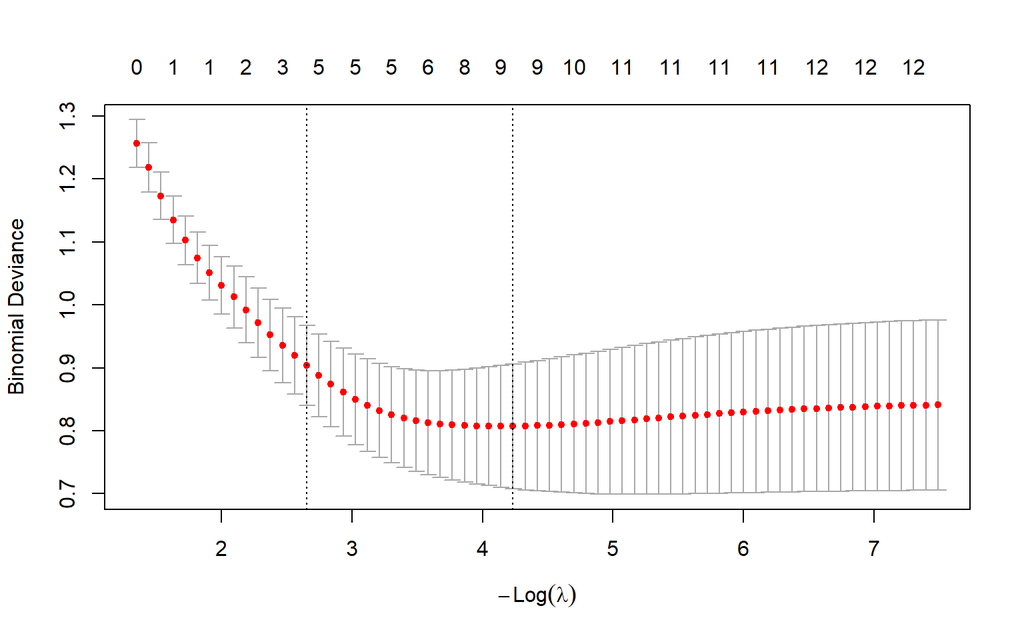

```r
x_train <- model.matrix(DEATH_EVENT ~ ., data = train)[, -1]
y_train <- train$DEATH_EVENT

# CV LASSO — finds the penalty (lambda) that minimises cross-validated error
lasso_cv <- cv.glmnet(x_train, y_train, family = "binomial", alpha = 1)
plot(lasso_cv)
```

```r
lasso_coefs  <- coef(lasso_cv, s = "lambda.1se")
selected_vars <- rownames(lasso_coefs)[which(lasso_coefs != 0)]
selected_vars <- selected_vars[selected_vars != "(Intercept)"]
print(selected_vars)
```

```
## [1] "age"               "ejection_fraction" "serum_creatinine"
## [4] "time"
```

```r
lasso_formula <- as.formula(paste("DEATH_EVENT ~", paste(selected_vars, collapse = " + ")))
```

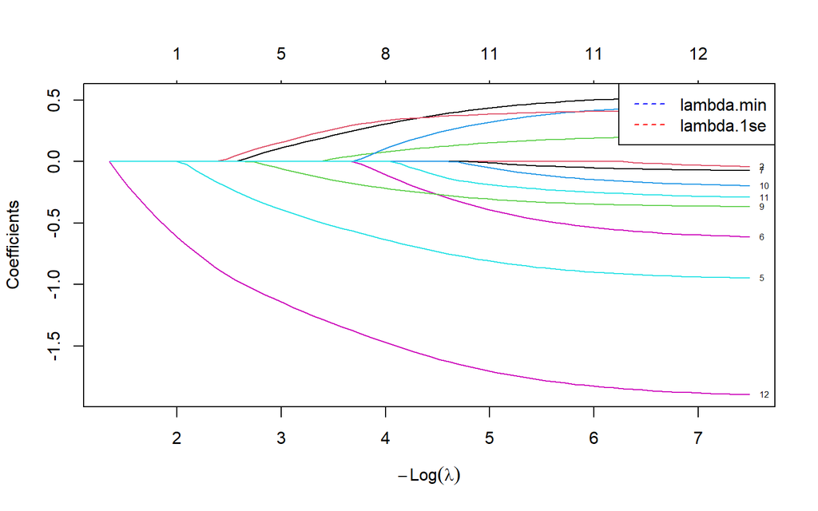

```r
# The coefficient path shows how each predictor's coefficient changes as the
# penalty increases from right (no penalty, all variables included) to left
# (high penalty, most variables zeroed out). Variables that survive to the far
# left are the most robustly important.
lasso_path <- glmnet(x_train, y_train, family = "binomial", alpha = 1)

plot(lasso_path, xvar = "lambda", label = TRUE)
abline(v = log(lasso_cv$lambda.min), lty = 2, col = "blue")
abline(v = log(lasso_cv$lambda.1se), lty = 2, col = "red")
legend("topright", legend = c("lambda.min", "lambda.1se"),
       col = c("blue", "red"), lty = 2)
```

## Cross-Validated Model Comparison

Now we train all four models under identical 10-fold CV conditions so performance comparisons are fair — every model sees the same folds.

```r
cv_logistic <- train(
  DEATH_EVENT ~ ., data = train,
  method    = "glm",
  family    = "binomial",
  trControl = train_control,
  metric    = "ROC"
)

cv_logistic_lasso <- train(
  lasso_formula, data = train,
  method    = "glm",
  family    = "binomial",
  trControl = train_control,
  metric    = "ROC"
)

cv_lda <- train(
  DEATH_EVENT ~ ., data = train,
  method    = "lda",
  trControl = train_control,
  metric    = "ROC"
)

cv_qda <- train(
  DEATH_EVENT ~ ., data = train,
  method    = "qda",
  trControl = train_control,
  metric    = "ROC"
)
```

```r
results <- resamples(list(
  Logistic       = cv_logistic,
  Logistic_LASSO = cv_logistic_lasso,
  LDA            = cv_lda,
  QDA            = cv_qda
))

summary(results)
```

```
##
## Call:
## summary.resamples(object = results)
##
## Models: Logistic, Logistic_LASSO, LDA, QDA
## Number of resamples: 10
##
## ROC
##                     Min.   1st Qu.    Median      Mean   3rd Qu.      Max. NA's
## Logistic       0.6785714 0.7641807 0.8968290 0.8627889 0.9575893 0.9921875    0
## Logistic_LASSO 0.8035714 0.8841912 0.8949580 0.8866662 0.9179688 0.9296875    0
## LDA            0.8359375 0.8610491 0.8897059 0.8920102 0.9095982 0.9687500    0
## QDA            0.6171875 0.7558594 0.8408613 0.8204175 0.8883929 0.9921875    0
##
## Sens
##                  Min.   1st Qu.    Median      Mean   3rd Qu. Max. NA's
## Logistic       0.8125 0.8281250 0.8750000 0.8827206 0.8823529    1    0
## Logistic_LASSO 0.7500 0.8750000 0.9099265 0.8952206 0.9402574    1    0
## LDA            0.7500 0.8363971 0.9062500 0.8904412 0.9402574    1    0
## QDA            0.8125 0.8750000 0.8750000 0.8952206 0.9264706    1    0
##
## Spec
##                     Min.   1st Qu.    Median      Mean   3rd Qu.      Max. NA's
## Logistic       0.2500000 0.5178571 0.6250000 0.6625000 0.8437500 1.0000000    0
## Logistic_LASSO 0.5000000 0.5848214 0.6250000 0.6875000 0.7500000 1.0000000    0
## LDA            0.2857143 0.6250000 0.7142857 0.6714286 0.7500000 0.8750000    0
## QDA            0.0000000 0.4062500 0.5000000 0.4553571 0.5535714 0.8571429    0
```

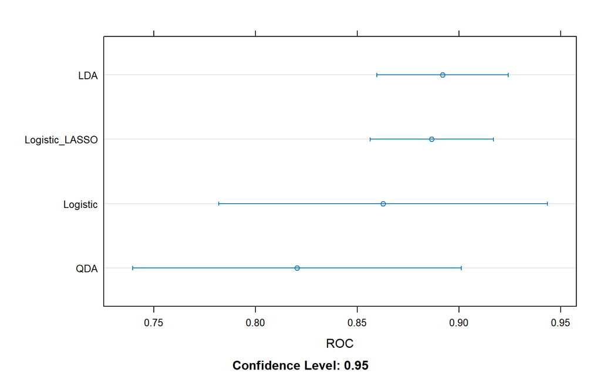

```r
dotplot(results, metric = "ROC")
```

The dot plot shows each model’s cross-validated AUC-ROC with 95% confidence intervals. AUC-ROC ranges from 0.5 (no better than random guessing) to 1.0 (perfect discrimination).

## Final Test Set Evaluation

```r
x_test <- model.matrix(DEATH_EVENT ~ ., data = test)[, -1]

preds <- data.frame(
  Logistic       = predict(cv_logistic,       test),
  Logistic_LASSO = predict(cv_logistic_lasso, test),
  LDA            = predict(cv_lda,            test),
  QDA            = predict(cv_qda,            test)
)

lapply(preds, function(p) confusionMatrix(p, test$DEATH_EVENT, positive = "Yes"))
```

```
## $Logistic
## Confusion Matrix and Statistics
##
##           Reference
## Prediction No Yes
##        No  36   8
##        Yes  4  11
##
##                Accuracy : 0.7966
##                  95% CI : (0.6717, 0.8902)
##     No Information Rate : 0.678
##     P-Value [Acc > NIR] : 0.03144
##
##                   Kappa : 0.507
##
##  Mcnemar's Test P-Value : 0.38648
##
##             Sensitivity : 0.5789
##             Specificity : 0.9000
##          Pos Pred Value : 0.7333
##          Neg Pred Value : 0.8182
##              Prevalence : 0.3220
##          Detection Rate : 0.1864
##    Detection Prevalence : 0.2542
##       Balanced Accuracy : 0.7395
##
##        'Positive' Class : Yes
##
##
## $Logistic_LASSO
## Confusion Matrix and Statistics
##
##           Reference
## Prediction No Yes
##        No  36   6
##        Yes  4  13
##
##                Accuracy : 0.8305
##                  95% CI : (0.7103, 0.9156)
##     No Information Rate : 0.678
```

[output cut: 60 more lines]

```
##                   Kappa : 0.2794
##
##  Mcnemar's Test P-Value : 0.02445
##
##             Sensitivity : 0.3158
##             Specificity : 0.9250
##          Pos Pred Value : 0.6667
##          Neg Pred Value : 0.7400
##              Prevalence : 0.3220
##          Detection Rate : 0.1017
##    Detection Prevalence : 0.1525
##       Balanced Accuracy : 0.6204
##
##        'Positive' Class : Yes
##
```

Reading the confusion matrices — for each model there are four possible outcomes for any given patient:

- **True Positive (TP)**: predicted to die, actually died — correct, clinically important
- **True Negative (TN)**: predicted to survive, actually survived — correct
- **False Negative (FN)**: predicted to survive, actually died — the most costly error
- **False Positive (FP)**: predicted to die, actually survived — causes unnecessary concern

In a clinical mortality prediction context, **sensitivity** (the proportion of actual deaths correctly identified) is the priority metric — missing a patient who will die is a more serious error than a false alarm. We focus on this when comparing models.

The **logistic regression (full) and LDA produce identical confusion matrices** — this is not a coincidence. LDA and logistic regression are asymptotically equivalent when the predictor distributions are approximately normal and the classes share the same covariance structure. Their convergence here suggests those assumptions hold reasonably well, and that a linear decision boundary is appropriate for this data.

**QDA’s sensitivity is notably lower** than the other models — it misclassifies a disproportionate number of actual deaths as survivors. Despite its higher specificity (it is good at identifying survivors), this trade-off is unfavourable for a clinical risk screening tool.

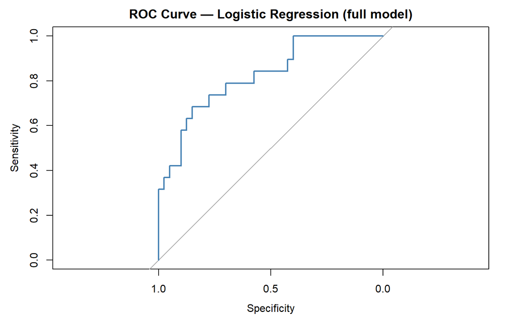

```r
prob_log <- predict(cv_logistic, test, type = "prob")[, 2]
roc_log  <- roc(test$DEATH_EVENT, prob_log)

plot(roc_log, main = "ROC Curve — Logistic Regression (full model)",
     col = "steelblue", lwd = 2)
```

```r
auc(roc_log)
```

```
## Area under the curve: 0.8224
```

The ROC curve plots sensitivity against (1 - specificity) across all possible classification thresholds. The default threshold of 0.5 — predicting “death” if the model assigns >50% probability — is one point on this curve. Depending on the clinical context, a different threshold might be preferred: if false negatives (missed deaths) are especially costly, lowering the threshold increases sensitivity at the expense of more false alarms.

## Summary of Findings

### Model performance

[output not shown]

### Clinical interpretation

The variables consistently selected by both LASSO and stepwise AIC — most notably **serum creatinine**, **ejection fraction**, and **follow-up time** — align with established clinical knowledge. Serum creatinine is a marker of kidney function, which deteriorates in advanced heart failure. Ejection fraction directly measures the heart’s pumping efficiency. Their emergence as the dominant predictors, across multiple independent selection methods, is reassuring that the models are capturing genuine clinical signal rather than noise.

### Limitations

- The dataset contains only 299 patients from a single centre (Faisalabad Institute of Cardiology, Pakistan, 2015). Performance on populations with different demographics or care standards may differ.
- The small sample produces wide confidence intervals around all performance estimates — the exact figures should be treated as indicative rather than precise.
- All models use the default 0.5 classification threshold. In practice, this threshold should be adjusted based on the relative costs of false negatives versus false positives in the specific clinical setting — a threshold of 0.3 would increase sensitivity at the cost of more false alarms, which may be the right trade-off for a screening tool.
- This is an observational dataset. The associations identified do not establish causality — they indicate which measurements are *predictive* of mortality, not necessarily which factors *cause* it.